# Figures + Analysis

Molly Wilson

Dec. 2018

Outline of selected figures and analyses:

- Grazing differences between islands: (site or island level?)  
  – ANOVAs to test statistical significance of differences here
- Total grazing impact of site-level biomass: measured vs. reported grazing rates (add line or color by feeding rate)
- Something looking at relationship with algal index vs. scarid biomass
- SEM?

Notes: - re: lms/gamms: have been stressed about collinearities in the data, but some aren’t that bad… return to models once I have a better handle on what I want to use (and make sure I’m looking at mixed effects models only?)  
- Exclude Barbuda from this analysis…?  
- From Nash et al. 2016:  
+ used GAMMs with site and reef zone as random effects + aggregated data to the site level + used mean or median values based on skew of different predictor/response variables (within each site)

```r
# set up
knitr::opts_chunk$set(echo = FALSE,
                      message = FALSE,
                      warning = FALSE)
library(startR)
library(here)
library(tidyverse)
```

```r
library(corrplot)
library(ggplot2)
library(RColorBrewer)
library(ggfortify)
library(ggsignif) # boxplot stats
library(EnvStats) # boxplot stats
library(car)
library(nlme)
library(gamm4)
```

# 1 Island - level differences in grazing rates

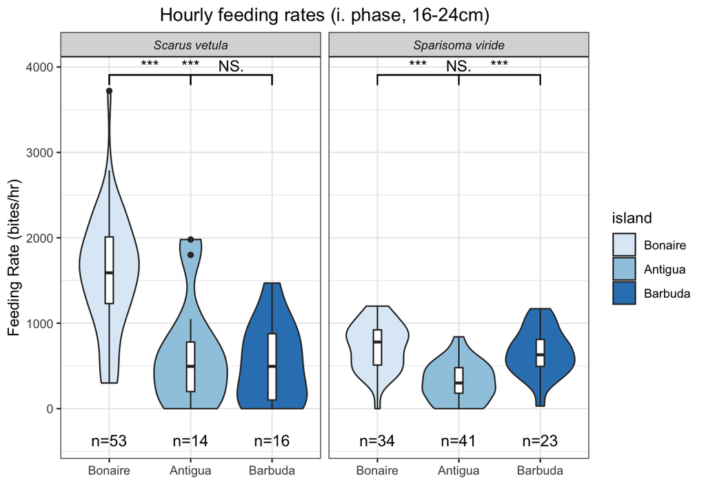

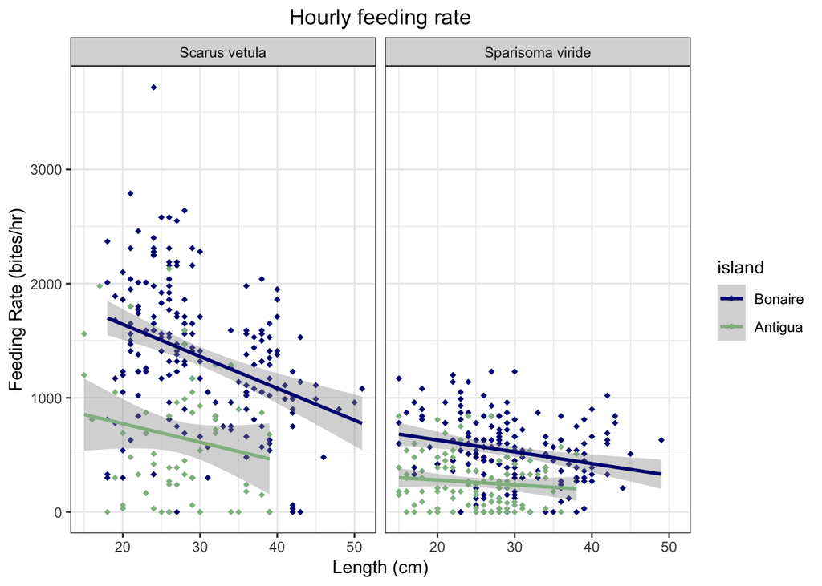

```
##
## Call:
## lm(formula = fr ~ length_cm, data = filter(sum_id, island ==
##     "Antigua" & phase == "i" & species_code == "stop"))
##
## Residuals:
##     Min      1Q  Median      3Q     Max
## -315.25 -173.55  -63.47  138.46  589.65
##
## Coefficients:
##             Estimate Std. Error t value Pr(>|t|)
## (Intercept)  445.037    108.268   4.111 9.31e-05 ***
## length_cm     -8.112      4.472  -1.814   0.0733 .
## ---
## Signif. codes:  0 '***' 0.001 '**' 0.01 '*' 0.05 '.' 0.1 ' ' 1
##
## Residual standard error: 211.3 on 82 degrees of freedom
## Multiple R-squared:  0.03858,    Adjusted R-squared:  0.02685
## F-statistic:  3.29 on 1 and 82 DF,  p-value: 0.07335
```

```
##
## Call:
## lm(formula = fr ~ length_cm, data = filter(sum_id, island ==
##     "Antigua" & phase == "i" & species_code == "qup"))
##
## Residuals:
##    Min     1Q Median     3Q    Max
## -818.9 -473.3 -105.4  360.2 1405.0
##
## Coefficients:
##             Estimate Std. Error t value Pr(>|t|)
## (Intercept)  1030.07     446.73   2.306    0.026 *
## length_cm     -11.73      17.17  -0.683    0.498
## ---
## Signif. codes:  0 '***' 0.001 '**' 0.01 '*' 0.05 '.' 0.1 ' ' 1
##
## Residual standard error: 601 on 43 degrees of freedom
## Multiple R-squared:  0.01074,    Adjusted R-squared:  -0.01226
## F-statistic: 0.4669 on 1 and 43 DF,  p-value: 0.4981
```

```
##
## Call:
## lm(formula = fr ~ length_cm, data = filter(sum_id, island ==
##     "Bonaire" & phase == "i" & species_code == "stop"))
##
## Residuals:
##     Min      1Q  Median      3Q     Max
## -655.76 -153.40    9.15  199.52  696.42
##
## Coefficients:
##             Estimate Std. Error t value Pr(>|t|)
## (Intercept) 1057.197    159.987   6.608 2.25e-09 ***
## length_cm    -17.454      6.153  -2.837  0.00557 **
## ---
## Signif. codes:  0 '***' 0.001 '**' 0.01 '*' 0.05 '.' 0.1 ' ' 1
##
## Residual standard error: 290.3 on 95 degrees of freedom
## Multiple R-squared:  0.07809,    Adjusted R-squared:  0.06838
## F-statistic: 8.047 on 1 and 95 DF,  p-value: 0.005572
```

```
##
## Call:
## lm(formula = fr ~ length_cm, data = filter(sum_id, island ==
##     "Bonaire" & phase == "i" & species_code == "qup"))
##
## Residuals:
##      Min       1Q   Median       3Q      Max
## -1601.66  -332.61   -12.37   397.51  2137.87
##
## Coefficients:
##             Estimate Std. Error t value Pr(>|t|)
## (Intercept) 1347.802    378.678   3.559 0.000552 ***
## length_cm      9.764     15.193   0.643 0.521792
## ---
## Signif. codes:  0 '***' 0.001 '**' 0.01 '*' 0.05 '.' 0.1 ' ' 1
##
## Residual standard error: 601.9 on 109 degrees of freedom
## Multiple R-squared:  0.003775,   Adjusted R-squared:  -0.005365
## F-statistic: 0.413 on 1 and 109 DF,  p-value: 0.5218
```

$$fr(Antigua, S. viride, i) = 445-8*L$$
$$fr(Antigua, S. vetula, i) = 1030-12*L$$
$$fr(Bonaire, S. viride, i) = 1057-17*L$$
$$fr(Bonaire, S. vetula, i) = 1347+10*L$$

## 1.1 Comparison to published equations

## 1.2 Predicted feeding rates and bite sizes from standard equations

Bite sizes as predicted by Bruggemann/Bozec:
$$bs(S. vetula) = 4.013*10^{-4}*L^2$$
$$bs(S. viride) = 5.257*10^{-4}*L^2$$

Feeding rates as published by Bruggemann/Bozec
$$fr(Published, S. viride, i) = 1089-17*L-56$$
*(extra term because phase modifier is not used here (i=1))*
$$fr(Published, S. vetula, initial) = 3329-33*L$$

## 1.3 adding predicted feeding rates from observed relationships

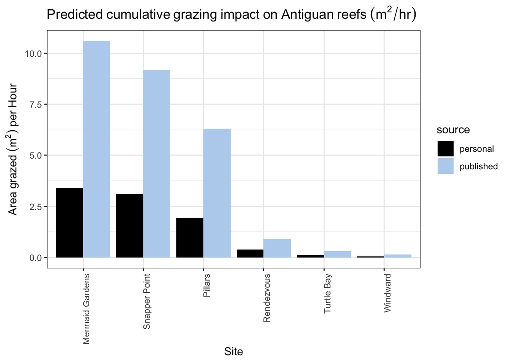